# Quantitative Analysis: Primer

PHRM7021

Adam La Caze

## Objectives

1. Demonstrate an understanding of key statistical concepts
2. Appropriately interpret common statistical tests used to describe populations, compare two groups, and assess correlations between two variables
3. Conduct a qualitative or quantitative analysis

## Resources

- Mackridge, A. J., & Rowe, P. H. (2018). A Practical Approach to Using Statistics in Health Research: From Planning to Reporting. New Jersey: Wiley.
- Illowsky, B., & Dean, S. (2018). Introductory Statistics. Houston: OpenStax.

## Where we want to get to

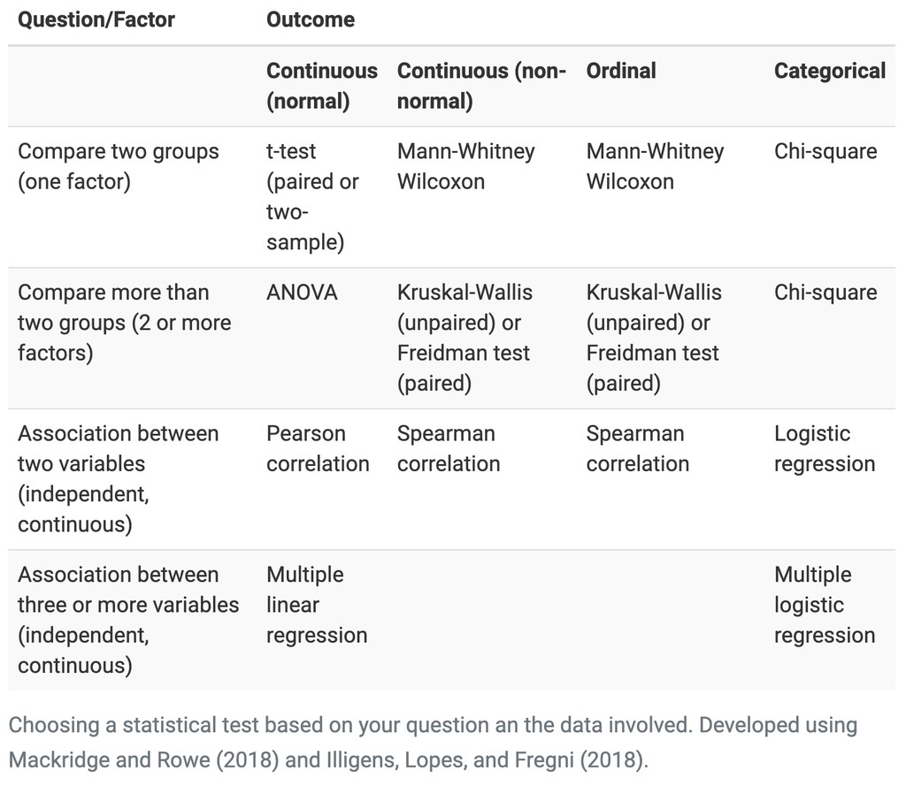

## Key questions

1. What type of data are you collecting? (i.e. nominal, ordinal, …)
2. What are the possible values of the variable? (i.e. the possible values for a die roll are [1,2,…,5,6])
3. How is the data distributed? (What is the probability of observing different values of the variable?)
4. Additional questions:
   1. Are the groups “related” or “independent”? (i.e. “paired” or “two sample”)
   2. Is the hypothesis directional or non-directional?

## What type of data are you collecting?

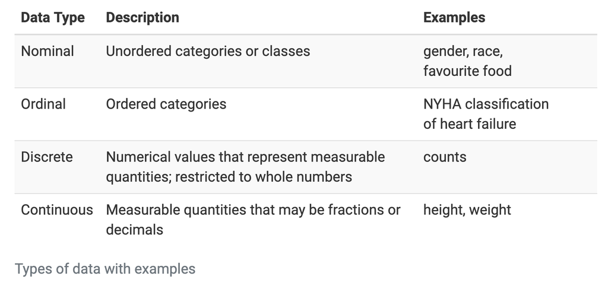

## How is the data distributed amongst the possible values?

- Thinking about the possible outcomes of an experiment, and
- Thinking about the probability of these outcomes

## Coin tossing experiment

Suppose we weren’t sure whether a coin was fair and we wanted to design an experiment to test whether it was. One strategy would be to record the outcome of 100 tosses of the coin and record how many Heads we observe.

```r
cointoss <- rbinom(10000, 100, 0.5)
```

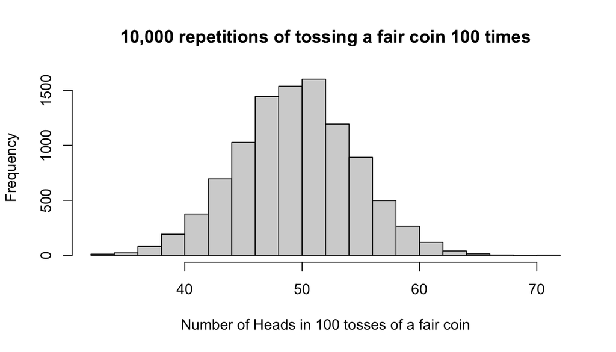

## Selecting a statistical test

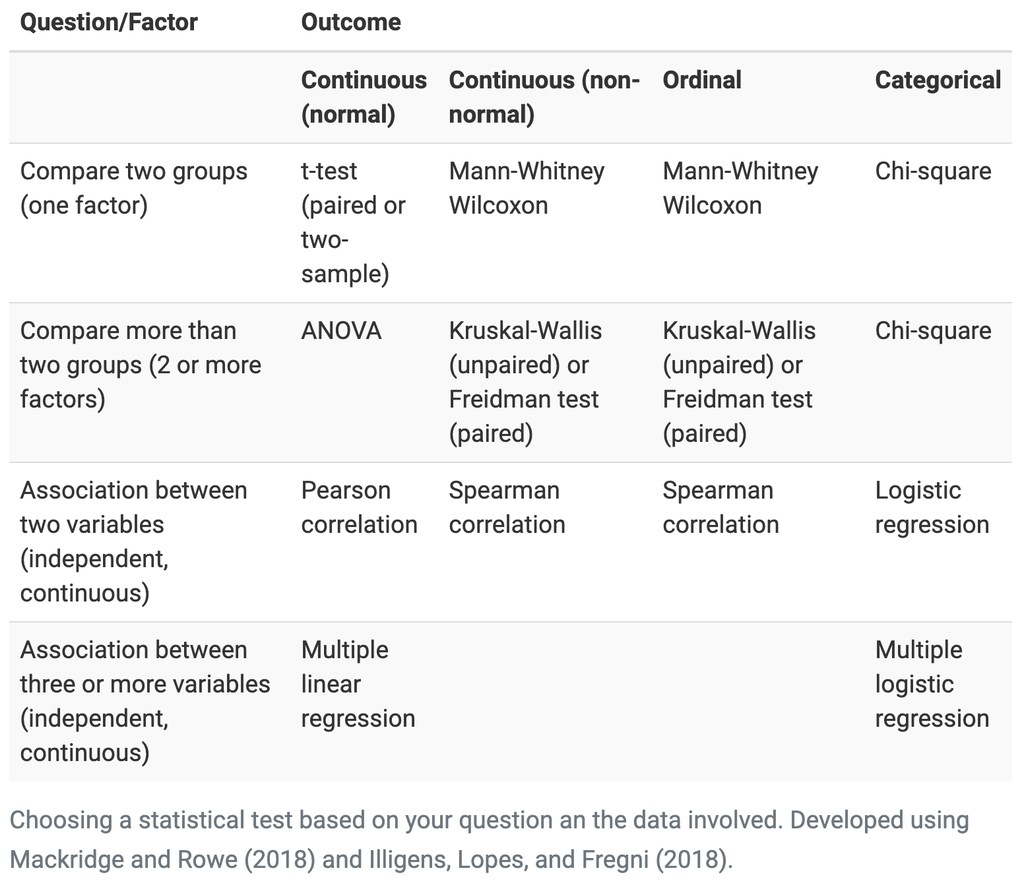

## Selecting a statistical test (our focus)

**Comparing two groups**

- t-test (paired, two-sample tests), `t.test()`
- Mann-Whitney Wilcoxon, `wilcox.test()`
- Chi-square test, `chisqu.test()`

**Assessing association**

- Pearson correlation, `cor()`, `cor.test()`
- Spearman correlation, `cor()`, `cor.test()`